# analysis

```python
import pandas as pd
import numpy as np
import matplotlib.pyplot as plt
import seaborn as sns
import xgboost as xgb
from xgboost import XGBClassifier
import sklearn
from sklearn.linear_model import LogisticRegression
from sklearn.model_selection import train_test_split
from sklearn.model_selection import cross_val_score
import sklearn.metrics as metrics
from scipy import stats
```

## Project Objective

The primary goal of this Jupyter notebook is to analyze heart failure data to identify key trends and observations. By understanding these patterns, we aim to better predict when a patient is at an increased risk of mortality due to a heart failure.

## Data Features

The dataset includes the following features:

- **Age**
- **Anaemia**
- **Creatinine Phosphokinase**
- **Diabetes**
- **Ejection Fraction**
- **High Blood Pressure**
- **Platelets**
- **Serum Creatinine**
- **Serum Sodium**
- **Sex**
- **Smoking**
- **Time**

## Model Development

Using the above features, the objective is to develop a predictive model that can accurately determine whether a death event has occurred due to a heart failure.

# Clean and Import data

```python
df=pd.read_csv("heart_failure_clinical_records.csv")
```

```python
df.isna().sum()
```

```
age                         0
anaemia                     0
creatinine_phosphokinase    0
diabetes                    0
ejection_fraction           0
high_blood_pressure         0
platelets                   0
serum_creatinine            0
serum_sodium                0
sex                         0
smoking                     0
time                        0
DEATH_EVENT                 0
dtype: int64
```

# visualizing data and feature engineering

```python
df.describe()
```

|  | age | anaemia | creatinine_phosphokinase | diabetes | ejection_fraction | high_blood_pressure | platelets | serum_creatinine | serum_sodium | sex | smoking | time | DEATH_EVENT |
| --- | --- | --- | --- | --- | --- | --- | --- | --- | --- | --- | --- | --- | --- |
| count | 5000.000000 | 5000.000000 | 5000.000000 | 5000.000000 | 5000.000000 | 5000.000000 | 5000.000000 | 5000.000000 | 5000.000000 | 5000.000000 | 5000.000000 | 5000.000000 | 5000.000000 |
| mean | 60.288736 | 0.474400 | 586.760600 | 0.439400 | 37.734600 | 0.364800 | 265075.404370 | 1.369106 | 136.808200 | 0.645600 | 0.311800 | 130.678800 | 0.313600 |
| std | 11.697243 | 0.499394 | 976.733979 | 0.496364 | 11.514855 | 0.481422 | 97999.758622 | 1.009750 | 4.464236 | 0.478379 | 0.463275 | 77.325928 | 0.464002 |
| min | 40.000000 | 0.000000 | 23.000000 | 0.000000 | 14.000000 | 0.000000 | 25100.000000 | 0.500000 | 113.000000 | 0.000000 | 0.000000 | 4.000000 | 0.000000 |
| 25% | 50.000000 | 0.000000 | 121.000000 | 0.000000 | 30.000000 | 0.000000 | 215000.000000 | 0.900000 | 134.000000 | 0.000000 | 0.000000 | 74.000000 | 0.000000 |
| 50% | 60.000000 | 0.000000 | 248.000000 | 0.000000 | 38.000000 | 0.000000 | 263358.030000 | 1.100000 | 137.000000 | 1.000000 | 0.000000 | 113.000000 | 0.000000 |
| 75% | 68.000000 | 1.000000 | 582.000000 | 1.000000 | 45.000000 | 1.000000 | 310000.000000 | 1.400000 | 140.000000 | 1.000000 | 1.000000 | 201.000000 | 1.000000 |
| max | 95.000000 | 1.000000 | 7861.000000 | 1.000000 | 80.000000 | 1.000000 | 850000.000000 | 9.400000 | 148.000000 | 1.000000 | 1.000000 | 285.000000 | 1.000000 |

Obsevering the measures of central tendency and spread some key takeaways from this dataset include that, respectively, 43% of patients have diabetes vs the IDF Diabetes Atlas belived that 10.5% of adults aged 20–79 worldwide had diabetes, 36% have high blood pressure vs the WHO stating that Hypertension affects 1 in 3 adults worldwide. ,47% have anaemia vs the global prevalence of anaemia across all ages was 24·3% via the NIH, and 31% smoke vs 22.3% of the world's population used tobacco reported by the WHO.Additionally the split between sex 64% vs 36% which is not representative of the whole population.Now it could be case that it is just representative of the population of heart failure patients.

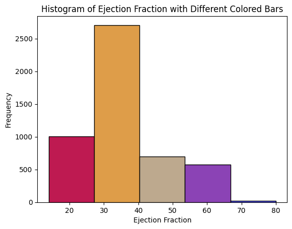

```python
n, bins, patches = plt.hist(df["ejection_fraction"], edgecolor="black", bins=5)

for patch in patches:
    patch.set_facecolor(np.random.rand(3))

plt.xlabel('Ejection Fraction')
plt.ylabel('Frequency')
plt.title('Histogram of Ejection Fraction with Different Colored Bars')
plt.show()
```

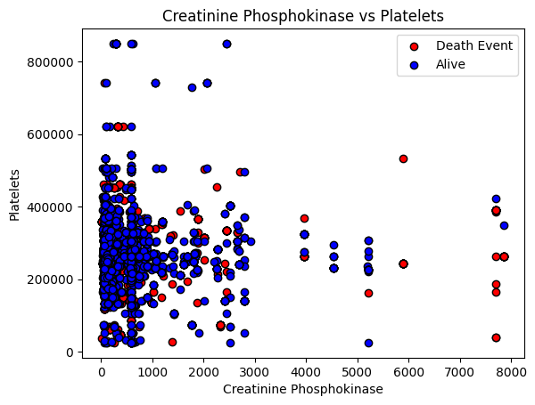

```python
death_event = df[df['DEATH_EVENT'] == 1]
alive = df[df['DEATH_EVENT'] == 0]

plt.scatter(death_event['creatinine_phosphokinase'], death_event['platelets'], color='red', edgecolors="black", label='Death Event')
plt.scatter(alive['creatinine_phosphokinase'], alive['platelets'], color='blue', edgecolors="black", label='Alive')

plt.title("Creatinine Phosphokinase vs Platelets")
plt.xlabel("Creatinine Phosphokinase")
plt.ylabel("Platelets")
plt.legend()
plt.show()
```

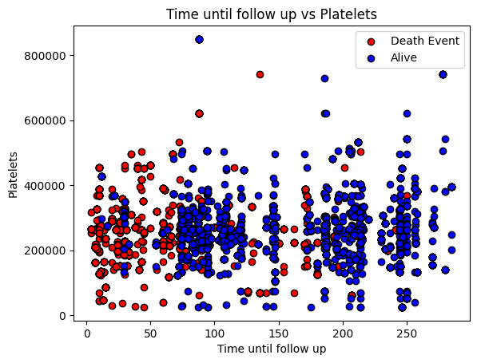

```python
plt.scatter(death_event['time'], death_event['platelets'], color='red', edgecolors="black", label='Death Event')
plt.scatter(alive['time'], alive['platelets'], color='blue', edgecolors="black", label='Alive')

plt.title("Time until follow up vs Platelets")
plt.xlabel("Time until follow up")
plt.ylabel("Platelets")
plt.legend()
plt.show()
```

Looking at time until follow up vs platelets we can see that majority of the patients hover around the 200000 to 400000 range but more interestingly that patients that have succumbed to death event seem to fit into bukets of time in which the are more likly to pass away.this indacting that it is possibly linearly separable in some sort of way.

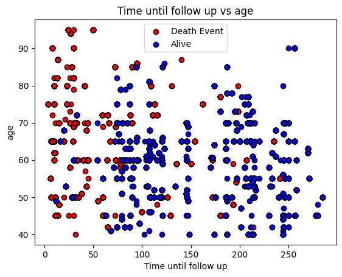

```python
plt.scatter(death_event['time'], death_event['age'], color='red', edgecolors="black", label='Death Event')
plt.scatter(alive['time'], alive['age'], color='blue', edgecolors="black", label='Alive')

plt.title("Time until follow up vs age")
plt.xlabel("Time until follow up")
plt.ylabel("age")
plt.legend()
plt.show()
```

Now taking a look at 'Time until follow-up' versus age, we can see more or less the same as the scatter plot above. The data is spread all around the grid. However, it does seem as if the data is much more linearly separable than in the chart before, with many of the patients dying close to their appointment.

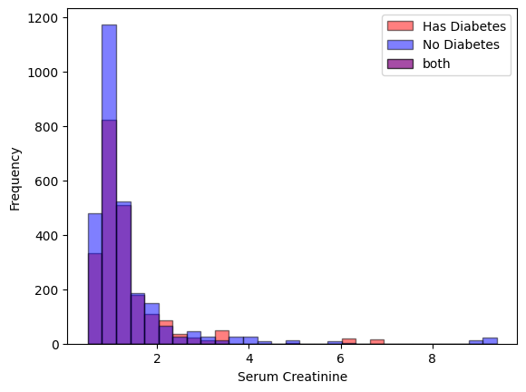

```python
has_diabetes=df[df['diabetes']==1]
no_diabetes = df[df['diabetes']==0]


bins = np.linspace(min(df['serum_creatinine']), max(df['serum_creatinine']), 30)

plt.hist(has_diabetes['serum_creatinine'], bins=bins, alpha=0.5, label='Has Diabetes', color='red', edgecolor='black')
plt.hist(no_diabetes['serum_creatinine'], bins=bins, alpha=0.5, label='No Diabetes', color='blue', edgecolor='black')
plt.hist([], bins=bins, alpha=0.7, label='both', color='purple', edgecolor='black')

plt.xlabel('Serum Creatinine')
plt.ylabel('Frequency')
plt.legend()
plt.show()
```

```python
df_mean_of_DEATH_EVENT = df.groupby("DEATH_EVENT").describe()

for stat in df_mean_of_DEATH_EVENT.columns.levels[0]:
    print(f"--- {stat.upper()} ---")
    display(df_mean_of_DEATH_EVENT[stat])
```

```
--- AGE ---
```

| DEATH_EVENT | count | mean | std | min | 25% | 50% | 75% | max |
| --- | --- | --- | --- | --- | --- | --- | --- | --- |
| 0 | 3432.0 | 58.316728 | 10.409036 | 40.0 | 50.0 | 59.0 | 65.0 | 90.0 |
| 1 | 1568.0 | 64.605020 | 13.118910 | 40.0 | 54.0 | 65.0 | 73.0 | 95.0 |

```
--- ANAEMIA ---
```

| DEATH_EVENT | count | mean | std | min | 25% | 50% | 75% | max |
| --- | --- | --- | --- | --- | --- | --- | --- | --- |
| 0 | 3432.0 | 0.456002 | 0.498133 | 0.0 | 0.0 | 0.0 | 1.0 | 1.0 |
| 1 | 1568.0 | 0.514668 | 0.499944 | 0.0 | 0.0 | 1.0 | 1.0 | 1.0 |

```
--- CREATININE_PHOSPHOKINASE ---
```

| DEATH_EVENT | count | mean | std | min | 25% | 50% | 75% | max |
| --- | --- | --- | --- | --- | --- | --- | --- | --- |
| 0 | 3432.0 | 534.144231 | 750.748108 | 25.0 | 114.5 | 231.0 | 582.0 | 7861.0 |
| 1 | 1568.0 | 701.926020 | 1337.926662 | 23.0 | 129.0 | 280.0 | 582.0 | 7861.0 |

```
--- DIABETES ---
```

| DEATH_EVENT | count | mean | std | min | 25% | 50% | 75% | max |
| --- | --- | --- | --- | --- | --- | --- | --- | --- |
| 0 | 3432.0 | 0.443182 | 0.496834 | 0.0 | 0.0 | 0.0 | 1.0 | 1.0 |
| 1 | 1568.0 | 0.431122 | 0.495391 | 0.0 | 0.0 | 0.0 | 1.0 | 1.0 |

```
--- EJECTION_FRACTION ---
```

| DEATH_EVENT | count | mean | std | min | 25% | 50% | 75% | max |
| --- | --- | --- | --- | --- | --- | --- | --- | --- |
| 0 | 3432.0 | 40.012529 | 10.558831 | 17.0 | 35.0 | 38.0 | 45.0 | 80.0 |
| 1 | 1568.0 | 32.748724 | 11.943309 | 14.0 | 25.0 | 30.0 | 38.0 | 70.0 |

```
--- HIGH_BLOOD_PRESSURE ---
```

| DEATH_EVENT | count | mean | std | min | 25% | 50% | 75% | max |
| --- | --- | --- | --- | --- | --- | --- | --- | --- |
| 0 | 3432.0 | 0.334207 | 0.471781 | 0.0 | 0.0 | 0.0 | 1.0 | 1.0 |
| 1 | 1568.0 | 0.431760 | 0.495479 | 0.0 | 0.0 | 0.0 | 1.0 | 1.0 |

```
--- PLATELETS ---
```

| DEATH_EVENT | count | mean | std | min | 25% | 50% | 75% | max |
| --- | --- | --- | --- | --- | --- | --- | --- | --- |
| 0 | 3432.0 | 267163.177028 | 96503.667982 | 25100.0 | 220000.0 | 263358.03 | 305000.0 | 850000.0 |
| 1 | 1568.0 | 260505.738705 | 101078.102673 | 25100.0 | 204000.0 | 263358.03 | 319000.0 | 742000.0 |

```
--- SERUM_CREATININE ---
```

| DEATH_EVENT | count | mean | std | min | 25% | 50% | 75% | max |
| --- | --- | --- | --- | --- | --- | --- | --- | --- |
| 0 | 3432.0 | 1.156672 | 0.632067 | 0.5 | 0.9 | 1.0 | 1.2 | 6.3 |
| 1 | 1568.0 | 1.834075 | 1.436236 | 0.6 | 1.1 | 1.4 | 1.9 | 9.4 |

```
--- SERUM_SODIUM ---
```

| DEATH_EVENT | count | mean | std | min | 25% | 50% | 75% | max |
| --- | --- | --- | --- | --- | --- | --- | --- | --- |
| 0 | 3432.0 | 137.494172 | 3.983055 | 113.0 | 136.0 | 137.0 | 140.0 | 148.0 |
| 1 | 1568.0 | 135.306760 | 5.055244 | 116.0 | 133.0 | 136.0 | 138.0 | 146.0 |

```
--- SEX ---
```

| DEATH_EVENT | count | mean | std | min | 25% | 50% | 75% | max |
| --- | --- | --- | --- | --- | --- | --- | --- | --- |
| 0 | 3432.0 | 0.627622 | 0.483509 | 0.0 | 0.0 | 1.0 | 1.0 | 1.0 |
| 1 | 1568.0 | 0.684949 | 0.464684 | 0.0 | 0.0 | 1.0 | 1.0 | 1.0 |

```
--- SMOKING ---
```

| DEATH_EVENT | count | mean | std | min | 25% | 50% | 75% | max |
| --- | --- | --- | --- | --- | --- | --- | --- | --- |
| 0 | 3432.0 | 0.308858 | 0.462090 | 0.0 | 0.0 | 0.0 | 1.0 | 1.0 |
| 1 | 1568.0 | 0.318240 | 0.465942 | 0.0 | 0.0 | 0.0 | 1.0 | 1.0 |

```
--- TIME ---
```

| DEATH_EVENT | count | mean | std | min | 25% | 50% | 75% | max |
| --- | --- | --- | --- | --- | --- | --- | --- | --- |
| 0 | 3432.0 | 158.232809 | 67.418180 | 12.0 | 95.00 | 174.0 | 213.0 | 285.0 |
| 1 | 1568.0 | 70.369260 | 61.811875 | 4.0 | 23.75 | 45.0 | 100.0 | 250.0 |

Observing the groups, it seems as if many of the features are significantly different for the group of people who have died versus those who are still alive. Therefore, I now want to perform significance testing to see if my hypothesis holds true.

```python
results = {}
for column in df.columns[:-1]:
    t_stat, p_val = stats.ttest_1samp(death_event[column], df[column].mean())
    results[column] = (t_stat, p_val)

for feature, (t_stat, p_val) in results.items():
    print(f"{feature}: t-statistic = {t_stat:.3f}, p-value = {p_val:.3f}")
```

```
age: t-statistic = 13.028, p-value = 0.000
anaemia: t-statistic = 3.189, p-value = 0.001
creatinine_phosphokinase: t-statistic = 3.408, p-value = 0.001
diabetes: t-statistic = -0.662, p-value = 0.508
ejection_fraction: t-statistic = -16.531, p-value = 0.000
high_blood_pressure: t-statistic = 5.351, p-value = 0.000
platelets: t-statistic = -1.790, p-value = 0.074
serum_creatinine: t-statistic = 12.820, p-value = 0.000
serum_sodium: t-statistic = -11.761, p-value = 0.000
sex: t-statistic = 3.353, p-value = 0.001
smoking: t-statistic = 0.547, p-value = 0.584
time: t-statistic = -38.636, p-value = 0.000
```

Features like age, anaemia, creatinine phosphokinase, ejection fraction, high blood pressure, serum creatinine, serum sodium, and time show significant differences, meaning that these factors are notably different in patients who died compared to the overall sample. In contrast, features like diabetes, platelets, and smoking do not show a statistically significant difference.

Also two most significant of these features being time and ejection_fraction both show a negative relationship between DEATH_EVENT.

```python
df["risk_val"] =  [int(x["smoking"]+x["diabetes"]+x['high_blood_pressure'] +x['anaemia']) for i,x in df.iterrows()]

risk_val_groups=df.groupby("risk_val")["DEATH_EVENT"].value_counts()
risk_val_groups
```

```
risk_val  DEATH_EVENT
0         0               334
          1               159
1         0              1401
          1               549
2         0              1239
          1               474
3         0               418
          1               382
4         0                40
          1                 4
Name: count, dtype: int64
```

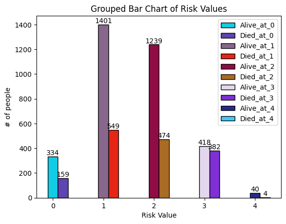

```python
for x in  range(5):
    bar1 = plt.bar([x], risk_val_groups[x][0], width=0.2, label=f"Alive_at_{x}", edgecolor="black", color=np.random.rand(1,3))
    plt.text(x, risk_val_groups[x][0] + 0.5, str(risk_val_groups[x][0]), ha='center', va='bottom')

    bar2 = plt.bar([x + 0.2], risk_val_groups[x][1], width=0.2, label=f'Died_at_{x}', edgecolor="black", color=np.random.rand(1,3))
    plt.text(x + 0.2, risk_val_groups[x][1] + 0.5, str(risk_val_groups[x][1]), ha='center', va='bottom')

plt.xlabel('Risk Value')
plt.ylabel('# of people')
plt.title('Grouped Bar Chart of Risk Values')
plt.legend()
plt.show()
```

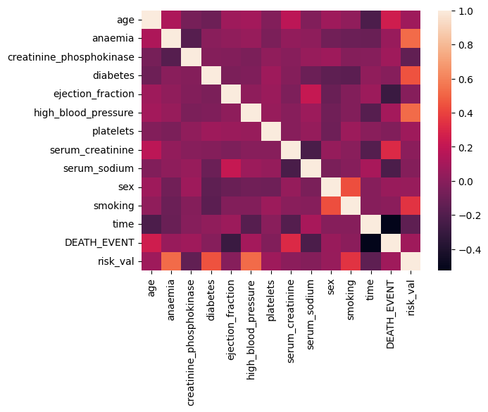

```python
sns.heatmap(df.corr())
```

# Model Builing

Here is a simple LogisticRegression model that uses all the factors given to predict if a DEATH_EVENT has occured

```python
X= df[['age', 'anaemia', 'creatinine_phosphokinase', 'diabetes',
       'ejection_fraction', 'high_blood_pressure', 'platelets',
       'serum_creatinine', 'serum_sodium', 'sex', 'smoking', 'time','risk_val']]
Y =df['DEATH_EVENT']

X_train, X_test, y_train, y_test = train_test_split(X,Y,test_size=0.33, random_state=42)
```

```python
logisticRegr = LogisticRegression(max_iter=10000)
```

```python
logisticRegr.fit(X_train,y_train)
logisticRegr.score(X_test,y_test)
y_pred=logisticRegr.predict(X_test)
cross_val_score(logisticRegr,X_test,y_test,cv=5)
```

```
array([0.84242424, 0.82424242, 0.81818182, 0.82121212, 0.85151515])
```

Using cross-validation, we can see that the general accuracy is around 80%, which is not bad. However, I want to better understand why the model is failing, so I'm going to take a look at the types of predictions it's getting wrong by looking at both the Recall and Precision of the model.

```python
print("Accuracy:",metrics.accuracy_score(y_test,y_pred))
print("Recall:",metrics.recall_score(y_test,y_pred))
print("Precision:",metrics.precision_score(y_test,y_pred))
```

```
Accuracy: 0.8242424242424242
Recall: 0.6607495069033531
Precision: 0.739514348785872
```

Instead we are now going to try using a gradient boosting model to see if we can learn how to predict wheather a death event has occured.

```python
bstmodel=XGBClassifier(n_estimators=5, max_depth=5, learning_rate=1, objective='binary:logistic')

bstmodel.fit(X_train,y_train)
y_pred=bstmodel.predict(X_test)
print("Accuracy:",metrics.accuracy_score(y_test,y_pred))
print("Recall:",metrics.recall_score(y_test,y_pred))
print("Precision:",metrics.precision_score(y_test,y_pred))
```

```
Accuracy: 0.9775757575757575
Recall: 0.9684418145956607
Precision: 0.958984375
```

Now we have created a model with nearly perfect prediction accuracy on whether a death event has occurred.I want to observe both the feature importances and decision tree to best understand how the model does so well.

```python
importances_lst = list(zip(bstmodel.feature_importances_, bstmodel.feature_names_in_))
sorted_importances = sorted(importances_lst, key=lambda x: x[0], reverse=True)
sorted_importances
```

```
[(0.38694644, 'time'),
 (0.11562104, 'serum_creatinine'),
 (0.08379025, 'age'),
 (0.08232668, 'ejection_fraction'),
 (0.07680288, 'diabetes'),
 (0.064862795, 'serum_sodium'),
 (0.058487408, 'risk_val'),
 (0.04956234, 'platelets'),
 (0.047345545, 'creatinine_phosphokinase'),
 (0.030681279, 'sex'),
 (0.0026634766, 'high_blood_pressure'),
 (0.0009098628, 'anaemia'),
 (0.0, 'smoking')]
```

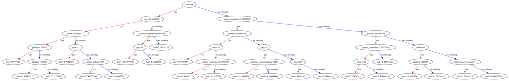

```python
xgb.plot_tree(bstmodel, num_trees=0, figsize=(50, 50))

fig = plt.gcf()
fig.set_size_inches(50, 50)
```

Reviewing the data generated by our model allows us to draw several conclusions and formulate numerous hypotheses about the critical factors in determining when someone is at risk of death. A primary and obvious indicator, as shown through charts, decision trees, correlations, and the model itself, is the role that the timing until the next appointment plays in predicting heart failure death. What remains a mystery, however, is exactly why this is the case. Could it be that the frequency of appointments, High frequency means that the patients have short times which is likely due to their poor conditions so it would make sense that it close to their time in general.Suggesting that being given a short time to return is an indication of death being imminent?At the same time you give someone a long enough time come back though and eventually they die so could it be the case that many patient are not getting check up regularly enough and they just die close to the appointment days.Whatever the case is it is clear thier is alot more that goes into understanding time until appointments relationship whith the death event.Another interesting aspects is seeing the discrepancy between the importance of diabetes in the model has opposed to looking at the correlation and hypothesis testing which give the indications that it woul not be as important as the other factors.smoking similar had outcomes on correlation and hypothesis testing and yet it was not as helpful in the model as diabetes.In the future I would love to have more data and information on some of the feature as think it's not accurate to categorize all smokers identically because there is a significant difference between smoking once a day and smoking five times a day. Differentiating between levels of smoking frequency can provide more precise insights into associated health risks and behaviors.